# Stat531_final

2024-04-16

### Explore periods

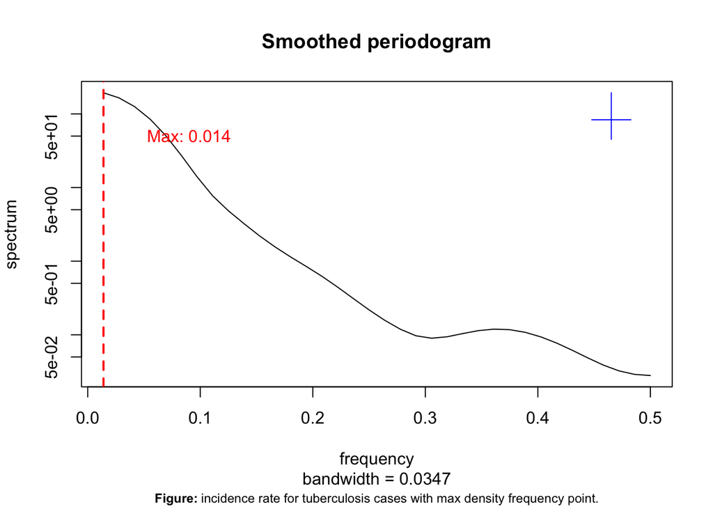

The plot shows no periodicity for our data, so SARIMA model should be excluded for analysis. Instead, ARIMA model should be considered  
given that our data clearly have a decreasing trend.

```r
select_arima_case <- model_selection_table(case_rate,
                                           max_p = 5, d = 1, max_q = 5,
                                           P = 0, D = 0, Q = 0, period = 0,
                                           simulation_times = 0)
```

### ARIMA model building and model diagnostics

based on the AIC and smallest root, the relatively suitable model we choose is ARIMA(1,1,5) with smallest root as 1.05

```r
library(knitr)
kable(select_arima_case$aic_table, digits = 3, caption = "AIC of some ARIMA models (incidence rate)")
```

AIC of some ARIMA models (incidence rate)

|  | MA0 | MA1 | MA2 | MA3 | MA4 | MA5 |
| --- | --- | --- | --- | --- | --- | --- |
| AR0 | 227.466 | 198.572 | 177.747 | 177.902 | 179.164 | 157.500 |
| AR1 | 168.015 | 171.767 | 156.462 | 157.843 | 159.138 | 153.924 |
| AR2 | 158.653 | 183.598 | 158.162 | 158.792 | 160.691 | 154.391 |
| AR3 | 155.969 | 156.142 | 157.979 | 159.065 | 155.865 | 150.530 |
| AR4 | 157.916 | 158.128 | 155.532 | 160.438 | 157.674 | 152.374 |
| AR5 | 155.682 | 156.226 | 146.519 | 148.383 | 149.200 | 150.802 |

```r
kable(select_arima_case$smllest_root_table, digits = 4, caption = "Smallest roots of ARIMA models (incidence rate)")
```

Smallest roots of ARIMA models (incidence rate)

|  | MA0 | MA1 | MA2 | MA3 | MA4 | MA5 |
| --- | --- | --- | --- | --- | --- | --- |
| AR0 | NA | 1.5785 | 1.0908 | 1.3152 | 1.1701 | 1.0237 |
| AR1 | 1.2261 | 1.2632 | 1.0156 | 1.0495 | 1.0155 | 1.0549 |
| AR2 | 1.0677 | 1.0003 | 1.0119 | 1.0217 | 1.0158 | 1.0556 |
| AR3 | 1.0227 | 1.0316 | 1.0210 | 1.0185 | 1.0163 | 1.0000 |
| AR4 | 1.0249 | 1.0300 | 1.0451 | 1.0122 | 1.0166 | 1.0000 |
| AR5 | 1.0113 | 1.0128 | 1.0000 | 1.0000 | 1.0000 | 1.0000 |

AR roots are 1.8434 + 0i. this root lies outside the unit circle on the complex plane. This indicates that the AR part of the ARIMA model is stationary. To determine invertibility, we need to ensure that all MA roots lie outside the unit circle. Because all the modulus of MA roots are larger than 1, we can say that the moving average part is also invertible. As a result, our ARIMA(1,1,5) can be reasonable treated as causal and invertible model.

As for its residuals, we find the residuals seems to be white noise. One thing worth noting is that residuals at earlier time have larger variance than residuals at later time. Therefore, homoscedasticity is violated. Heteroscedasticity does not bias the coefficient estimates themselves, but it can lead to biased estimates of the standard errors, which in turn can mislead inferences made regarding the significance of predictors. In the QQ plot, a heavy-tailed distribution is obvious and this shows that the residual doesn’t obey normal distribution. In the ACF plot, nothing significant is observed, therefore, we can conclude that the residual is uncorrelated. Overall, the diagnosis conducted here suggests that a simple ARIMA model is not a very suitable model for tuberculosis incidence rate data because the violation of normality and homoscedasticity makes the statistical inference hard to proceed.

```
## AR roots: 1.8434+0i
## Mod of AR roots: 1.8434
## MA roots: 0.7508+0.7411i -0.3141+1.027i -0.3141-1.027i 0.7508-0.7411i -1.2645+0i
## Mod of MA roots: 1.0549 1.0739 1.0739 1.0549 1.2645
```

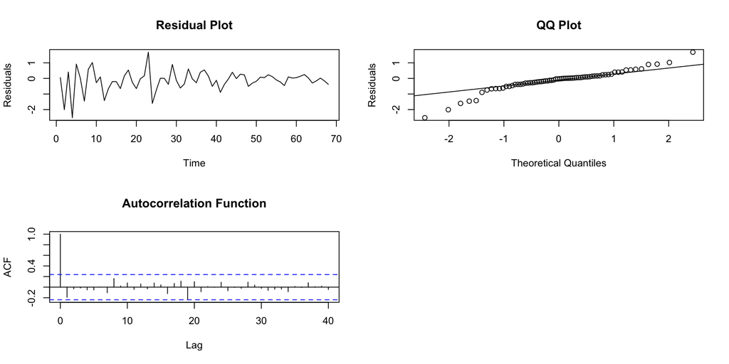